# Linear Regression example

Marco Pasin

22 giugno 2019

```r
library("MASS")
library("ISLR")
library("tidyverse")
```

Let’s use the `Boston` dataset.

### Quickly explore data

```r
glimpse(Boston)
```

```
## Observations: 506
## Variables: 14
## $ crim    <dbl> 0.00632, 0.02731, 0.02729, 0.03237, 0.06905, 0.02985, ...
## $ zn      <dbl> 18.0, 0.0, 0.0, 0.0, 0.0, 0.0, 12.5, 12.5, 12.5, 12.5,...
## $ indus   <dbl> 2.31, 7.07, 7.07, 2.18, 2.18, 2.18, 7.87, 7.87, 7.87, ...
## $ chas    <int> 0, 0, 0, 0, 0, 0, 0, 0, 0, 0, 0, 0, 0, 0, 0, 0, 0, 0, ...
## $ nox     <dbl> 0.538, 0.469, 0.469, 0.458, 0.458, 0.458, 0.524, 0.524...
## $ rm      <dbl> 6.575, 6.421, 7.185, 6.998, 7.147, 6.430, 6.012, 6.172...
## $ age     <dbl> 65.2, 78.9, 61.1, 45.8, 54.2, 58.7, 66.6, 96.1, 100.0,...
## $ dis     <dbl> 4.0900, 4.9671, 4.9671, 6.0622, 6.0622, 6.0622, 5.5605...
## $ rad     <int> 1, 2, 2, 3, 3, 3, 5, 5, 5, 5, 5, 5, 5, 4, 4, 4, 4, 4, ...
## $ tax     <dbl> 296, 242, 242, 222, 222, 222, 311, 311, 311, 311, 311,...
## $ ptratio <dbl> 15.3, 17.8, 17.8, 18.7, 18.7, 18.7, 15.2, 15.2, 15.2, ...
## $ black   <dbl> 396.90, 396.90, 392.83, 394.63, 396.90, 394.12, 395.60...
## $ lstat   <dbl> 4.98, 9.14, 4.03, 2.94, 5.33, 5.21, 12.43, 19.15, 29.9...
## $ medv    <dbl> 24.0, 21.6, 34.7, 33.4, 36.2, 28.7, 22.9, 27.1, 16.5, ...
```

```r
?Boston
```

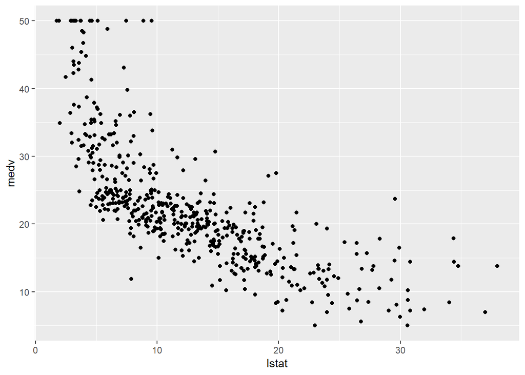

```r
Boston %>%
  ggplot(aes(lstat, medv)) +
  geom_point()
```

### Linear Regression

Let’s fit a simple model using lstat as single predictor.

```r
fit1 <- Boston %>%
  lm(medv ~ lstat, .)

fit1
```

```
##
## Call:
## lm(formula = medv ~ lstat, data = .)
##
## Coefficients:
## (Intercept)        lstat
##       34.55        -0.95
```

```r
summary(fit1)
```

```
##
## Call:
## lm(formula = medv ~ lstat, data = .)
##
## Residuals:
##     Min      1Q  Median      3Q     Max
## -15.168  -3.990  -1.318   2.034  24.500
##
## Coefficients:
##             Estimate Std. Error t value Pr(>|t|)
## (Intercept) 34.55384    0.56263   61.41   <2e-16 ***
## lstat       -0.95005    0.03873  -24.53   <2e-16 ***
## ---
## Signif. codes:  0 '***' 0.001 '**' 0.01 '*' 0.05 '.' 0.1 ' ' 1
##
## Residual standard error: 6.216 on 504 degrees of freedom
## Multiple R-squared:  0.5441, Adjusted R-squared:  0.5432
## F-statistic: 601.6 on 1 and 504 DF,  p-value: < 2.2e-16
```

Both look very significant.Coefficient for lstat is negative and very significant. Coeeficient for intercept also very significant though it’s not very interesting for us.

We can add the linear model fit to the plot.

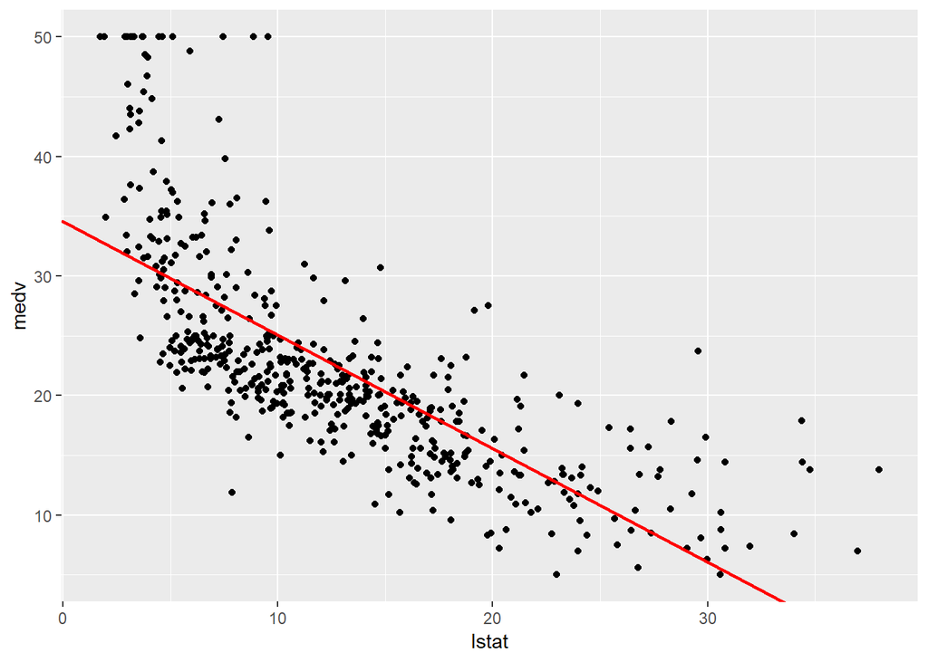

```r
Boston %>%
  ggplot(aes(lstat, medv)) +
  geom_point() +
  geom_abline(intercept = fit1$coefficients[1], slope= fit1$coefficients[2],
              col = "red", size = 1)
```

Find CI for coefficients (95% CI for both)

```r
confint(fit1)
```

```
##                 2.5 %     97.5 %
## (Intercept) 33.448457 35.6592247
## lstat       -1.026148 -0.8739505
```

Lets make some predictions using 3 new values for lstat. Ask aso for CI along with predictions.

```r
fit1 %>%
  predict(data.frame(lstat=c(5, 10, 15)), interval = "confidence")
```

```
##        fit      lwr      upr
## 1 29.80359 29.00741 30.59978
## 2 25.05335 24.47413 25.63256
## 3 20.30310 19.73159 20.87461
```

We get the fit fot th 3 values, and then the lower and upper confidence bands.

So, that’s simple linear regression :)

Let’s move now to **multiple linear regression**.

### Multiple linear regression

Fit a model with lstat and age

```r
fit2 <- Boston %>%
  lm(medv ~ lstat + age, .)

summary(fit2)
```

```
##
## Call:
## lm(formula = medv ~ lstat + age, data = .)
##
## Residuals:
##     Min      1Q  Median      3Q     Max
## -15.981  -3.978  -1.283   1.968  23.158
##
## Coefficients:
##             Estimate Std. Error t value Pr(>|t|)
## (Intercept) 33.22276    0.73085  45.458  < 2e-16 ***
## lstat       -1.03207    0.04819 -21.416  < 2e-16 ***
## age          0.03454    0.01223   2.826  0.00491 **
## ---
## Signif. codes:  0 '***' 0.001 '**' 0.01 '*' 0.05 '.' 0.1 ' ' 1
##
## Residual standard error: 6.173 on 503 degrees of freedom
## Multiple R-squared:  0.5513, Adjusted R-squared:  0.5495
## F-statistic:   309 on 2 and 503 DF,  p-value: < 2.2e-16
```

Age is also significant, quite strongly, but not as significant as lstat. R2 also improved a bit.

Now we fit a model considering all variables in the dataset as predictors.

```r
fit3 <- Boston %>%
  lm(medv ~ ., .)

summary(fit3)
```

```
##
## Call:
## lm(formula = medv ~ ., data = .)
##
## Residuals:
##     Min      1Q  Median      3Q     Max
## -15.595  -2.730  -0.518   1.777  26.199
##
## Coefficients:
##               Estimate Std. Error t value Pr(>|t|)
## (Intercept)  3.646e+01  5.103e+00   7.144 3.28e-12 ***
## crim        -1.080e-01  3.286e-02  -3.287 0.001087 **
## zn           4.642e-02  1.373e-02   3.382 0.000778 ***
## indus        2.056e-02  6.150e-02   0.334 0.738288
## chas         2.687e+00  8.616e-01   3.118 0.001925 **
## nox         -1.777e+01  3.820e+00  -4.651 4.25e-06 ***
## rm           3.810e+00  4.179e-01   9.116  < 2e-16 ***
## age          6.922e-04  1.321e-02   0.052 0.958229
## dis         -1.476e+00  1.995e-01  -7.398 6.01e-13 ***
## rad          3.060e-01  6.635e-02   4.613 5.07e-06 ***
## tax         -1.233e-02  3.760e-03  -3.280 0.001112 **
## ptratio     -9.527e-01  1.308e-01  -7.283 1.31e-12 ***
## black        9.312e-03  2.686e-03   3.467 0.000573 ***
## lstat       -5.248e-01  5.072e-02 -10.347  < 2e-16 ***
## ---
## Signif. codes:  0 '***' 0.001 '**' 0.01 '*' 0.05 '.' 0.1 ' ' 1
##
## Residual standard error: 4.745 on 492 degrees of freedom
## Multiple R-squared:  0.7406, Adjusted R-squared:  0.7338
## F-statistic: 108.1 on 13 and 492 DF,  p-value: < 2.2e-16
```

We see a lot of coefficients now. Some are significant , some not.

Age (which earlier was significant) is not longer significant. There are a lot of other predictors which are correlated with age, and in this context age is not longer required.

Following plots give various views of the model. The obj. is to look for non-linearity.

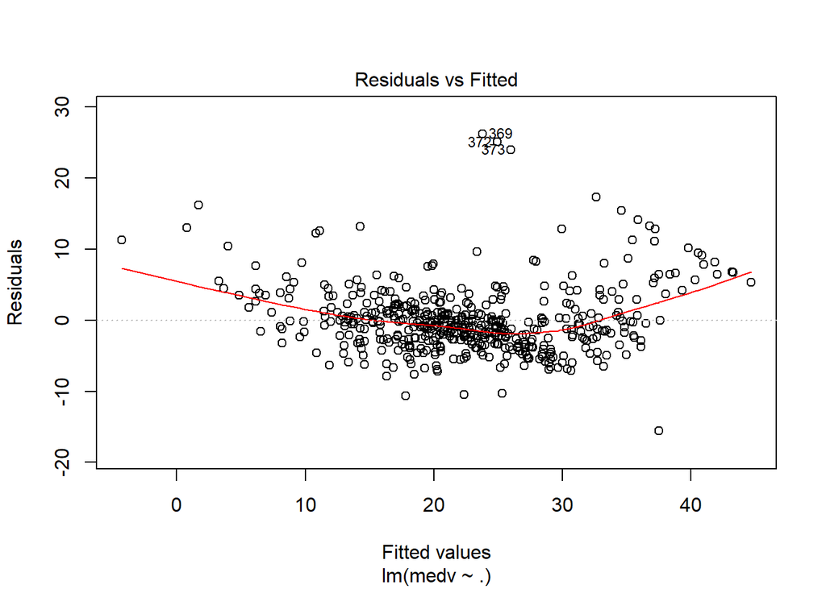

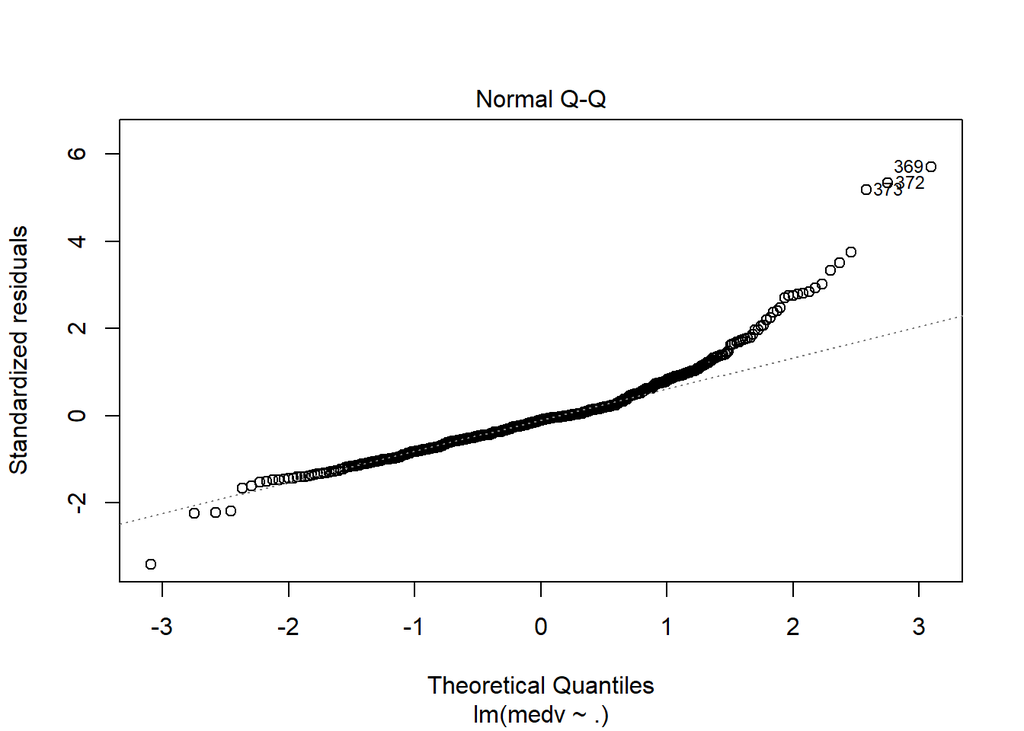

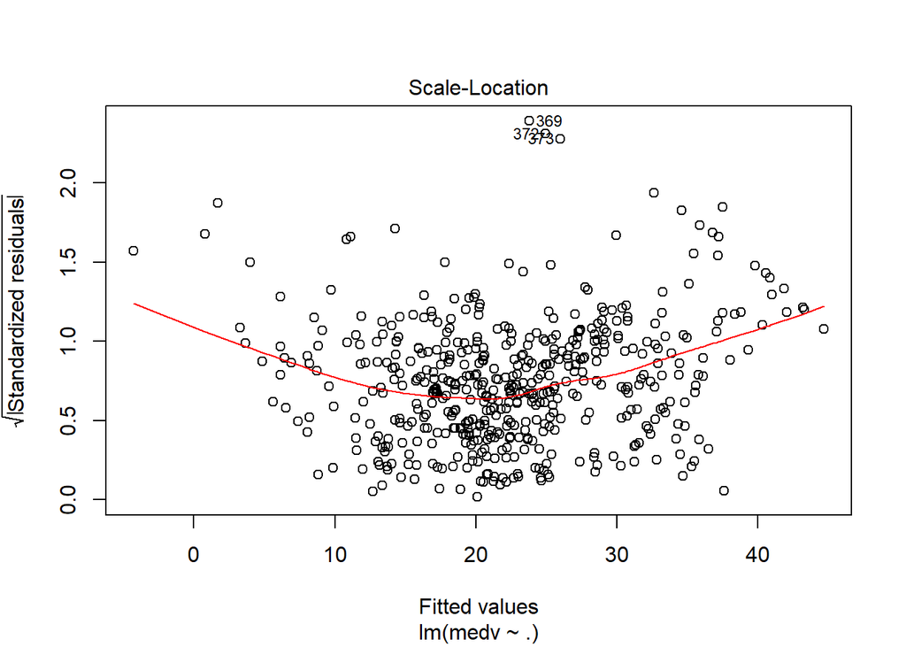

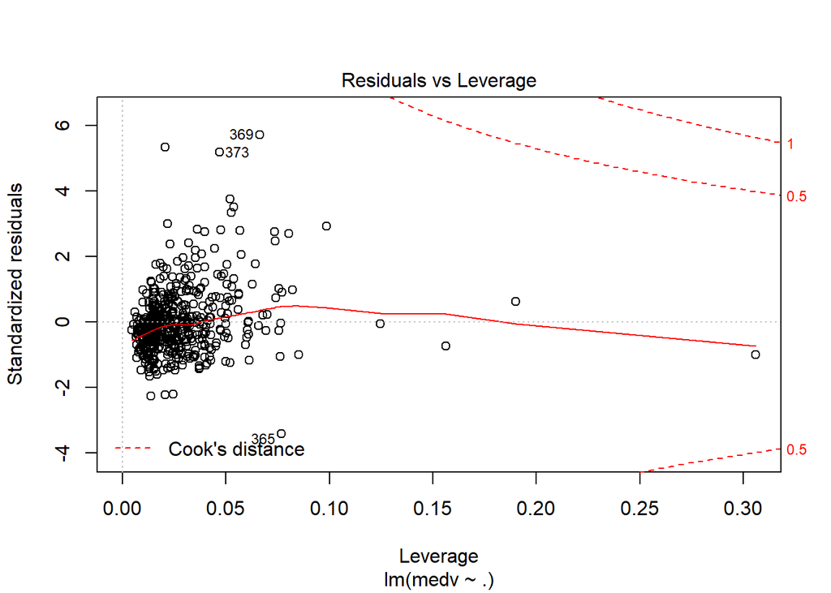

```r
plot(fit3)
```

There seem to be some *non-linearity*.

We can update the model and remove not significant predictors.

```r
fit4 <- Boston %>%
  lm(medv ~ .-age-indus, .)

summary(fit4)
```

```
##
## Call:
## lm(formula = medv ~ . - age - indus, data = .)
##
## Residuals:
##      Min       1Q   Median       3Q      Max
## -15.5984  -2.7386  -0.5046   1.7273  26.2373
##
## Coefficients:
##               Estimate Std. Error t value Pr(>|t|)
## (Intercept)  36.341145   5.067492   7.171 2.73e-12 ***
## crim         -0.108413   0.032779  -3.307 0.001010 **
## zn            0.045845   0.013523   3.390 0.000754 ***
## chas          2.718716   0.854240   3.183 0.001551 **
## nox         -17.376023   3.535243  -4.915 1.21e-06 ***
## rm            3.801579   0.406316   9.356  < 2e-16 ***
## dis          -1.492711   0.185731  -8.037 6.84e-15 ***
## rad           0.299608   0.063402   4.726 3.00e-06 ***
## tax          -0.011778   0.003372  -3.493 0.000521 ***
## ptratio      -0.946525   0.129066  -7.334 9.24e-13 ***
## black         0.009291   0.002674   3.475 0.000557 ***
## lstat        -0.522553   0.047424 -11.019  < 2e-16 ***
## ---
## Signif. codes:  0 '***' 0.001 '**' 0.01 '*' 0.05 '.' 0.1 ' ' 1
##
## Residual standard error: 4.736 on 494 degrees of freedom
## Multiple R-squared:  0.7406, Adjusted R-squared:  0.7348
## F-statistic: 128.2 on 11 and 494 DF,  p-value: < 2.2e-16
```

### Non linear terms and interactions

Here the first thing we do is make a fit where we put an interaction between lstat and age. Star in the formula means that we are gonna have main effect for each and the interaction.

```r
fit5 <- Boston %>%
  lm(medv ~ lstat * age, .)

summary(fit5)
```

```
##
## Call:
## lm(formula = medv ~ lstat * age, data = .)
##
## Residuals:
##     Min      1Q  Median      3Q     Max
## -15.806  -4.045  -1.333   2.085  27.552
##
## Coefficients:
##               Estimate Std. Error t value Pr(>|t|)
## (Intercept) 36.0885359  1.4698355  24.553  < 2e-16 ***
## lstat       -1.3921168  0.1674555  -8.313 8.78e-16 ***
## age         -0.0007209  0.0198792  -0.036   0.9711
## lstat:age    0.0041560  0.0018518   2.244   0.0252 *
## ---
## Signif. codes:  0 '***' 0.001 '**' 0.01 '*' 0.05 '.' 0.1 ' ' 1
##
## Residual standard error: 6.149 on 502 degrees of freedom
## Multiple R-squared:  0.5557, Adjusted R-squared:  0.5531
## F-statistic: 209.3 on 3 and 502 DF,  p-value: < 2.2e-16
```

While the main effect for age is not significant here, the interaction is somewhat significant.

Since in a previous scatter plot we saw there was a non-linear pattern between lstat and response variable, next thing we do is take this into account and put lstat in a quadratic term.

```r
fit6 <- Boston %>%
  lm(medv ~ lstat + I(lstat^2), .)

summary(fit6)
```

```
##
## Call:
## lm(formula = medv ~ lstat + I(lstat^2), data = .)
##
## Residuals:
##      Min       1Q   Median       3Q      Max
## -15.2834  -3.8313  -0.5295   2.3095  25.4148
##
## Coefficients:
##              Estimate Std. Error t value Pr(>|t|)
## (Intercept) 42.862007   0.872084   49.15   <2e-16 ***
## lstat       -2.332821   0.123803  -18.84   <2e-16 ***
## I(lstat^2)   0.043547   0.003745   11.63   <2e-16 ***
## ---
## Signif. codes:  0 '***' 0.001 '**' 0.01 '*' 0.05 '.' 0.1 ' ' 1
##
## Residual standard error: 5.524 on 503 degrees of freedom
## Multiple R-squared:  0.6407, Adjusted R-squared:  0.6393
## F-statistic: 448.5 on 2 and 503 DF,  p-value: < 2.2e-16
```

Not surprisingly, both coefficient, the linear and quadratic, are strongly significant.

Add a qudratic fit in the scatter plot.

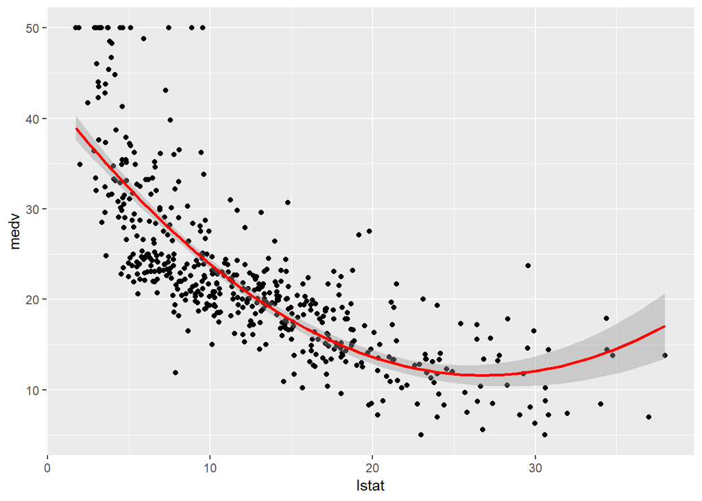

```r
Boston %>%
  ggplot(aes(lstat, medv)) +
  geom_point() +
  geom_smooth(aes(y = medv),method = "lm", formula = y ~ x + I(x^2),
              col="red", size = 1)
```

Last, we are gonna fit response variable as a **polynomial** of degree four in lstat.

```r
fit7 <- Boston %>%
  lm(medv ~ poly(lstat, 4), .)

summary(fit7)
```

```
##
## Call:
## lm(formula = medv ~ poly(lstat, 4), data = .)
##
## Residuals:
##     Min      1Q  Median      3Q     Max
## -13.563  -3.180  -0.632   2.283  27.181
##
## Coefficients:
##                  Estimate Std. Error t value Pr(>|t|)
## (Intercept)       22.5328     0.2347  95.995  < 2e-16 ***
## poly(lstat, 4)1 -152.4595     5.2801 -28.874  < 2e-16 ***
## poly(lstat, 4)2   64.2272     5.2801  12.164  < 2e-16 ***
## poly(lstat, 4)3  -27.0511     5.2801  -5.123 4.29e-07 ***
## poly(lstat, 4)4   25.4517     5.2801   4.820 1.90e-06 ***
## ---
## Signif. codes:  0 '***' 0.001 '**' 0.01 '*' 0.05 '.' 0.1 ' ' 1
##
## Residual standard error: 5.28 on 501 degrees of freedom
## Multiple R-squared:  0.673,  Adjusted R-squared:  0.6704
## F-statistic: 257.8 on 4 and 501 DF,  p-value: < 2.2e-16
```

Add the polynomial fit in the scatter plot and compare them.

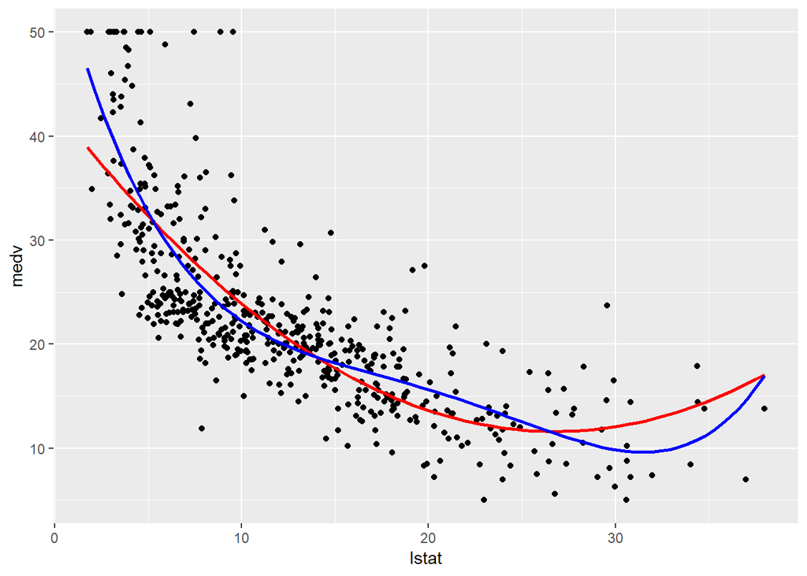

```r
Boston %>%
  ggplot(aes(lstat, medv)) +
  geom_point() +
  geom_smooth(aes(y = medv),method = "lm", formula = y ~ x + I(x^2),
              col="red", size = 1, se=FALSE) +
  geom_smooth(aes(y = medv),method = "lm", formula = y ~ poly(x, 4),
              col="blue", size = 1, se = FALSE)
```

It seems that the polinomial starts to **overfit** the data a bit too much, especially in the right tail it seems to folllow the data too strictly.